# Лабораторная работа №15

Дисциплина: Администрирование сетевых подсистем

Бахи сиди али темассини

1032234211@pfur.ru

Российский университет дружбы народов

2026-02-16

# Цель работы

## Цель работы

- Получение навыков по работе с журналами системных событий

# Выполнение лабораторной работы

## Настройка сервера сетевого журнала

- Переход в каталог `/etc/rsyslog.d`
- Создание файла `netlog-server.conf`
- Подготовка конфигурации для сетевого хранения журналов

[figure not shown]

Рисунок 1: Создание файла конфигурации rsyslog netlog-server.conf

- Включён приём журналов по TCP-порту 514
- Загружен модуль `imtcp`
- Активирован сервер ввода `$InputTCPServerRun 514`

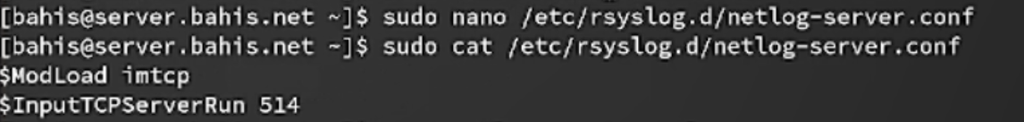

Рисунок 2: Настройка приёма журналов по TCP 514 в rsyslog

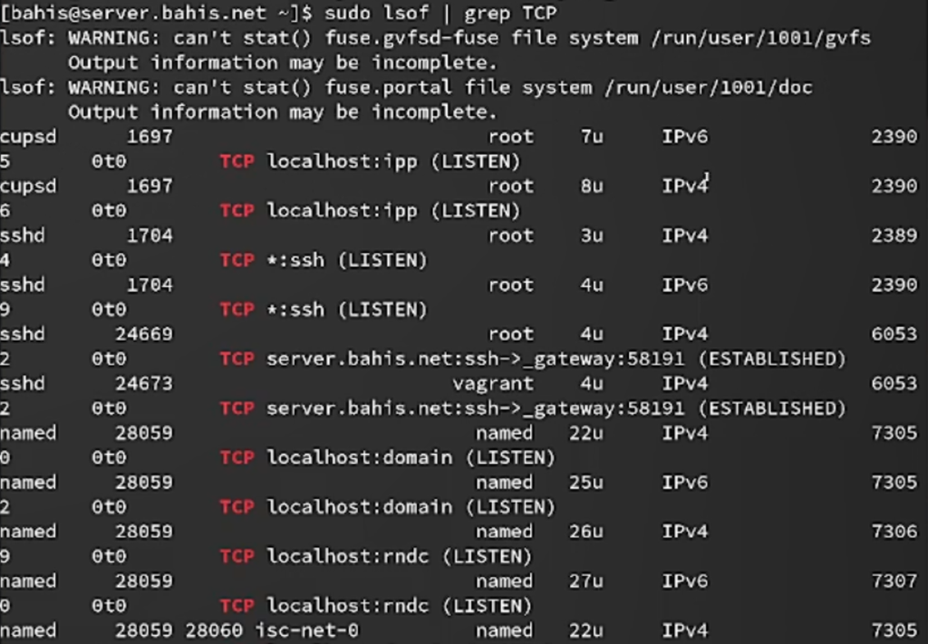

- Открыт TCP-порт 514 в `firewalld`
- Добавлено временное и постоянное правило
- Разрешён приём сетевых сообщений журнала

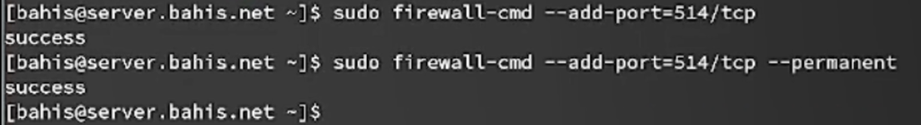

Рисунок 4: Настройка firewalld для открытия TCP-порта 514

## Настройка клиента сетевого журнала

- Переход в каталог `/etc/rsyslog.d`
- Создание файла `netlog-client.conf`
- Подготовка конфигурации отправки журналов

[figure not shown]

Рисунок 5: Создание файла конфигурации netlog-client.conf на клиенте

- Настроено перенаправление `*.* @@server.bahis.net:514`
- Использован протокол TCP (`@@`)
- Организована передача всех сообщений на сервер
- Перезапущена служба `rsyslog`
- Применена новая конфигурация клиента

[figure not shown]

Рисунок 6: Настройка перенаправления журналов на сервер по TCP 514

## Просмотр журнала

[figure not shown]

Рисунок 7: Просмотр журнала /var/log/messages на сервере

- Запущена программа `gnome-system-monitor`
- Отображены процессы, PID, использование CPU и памяти

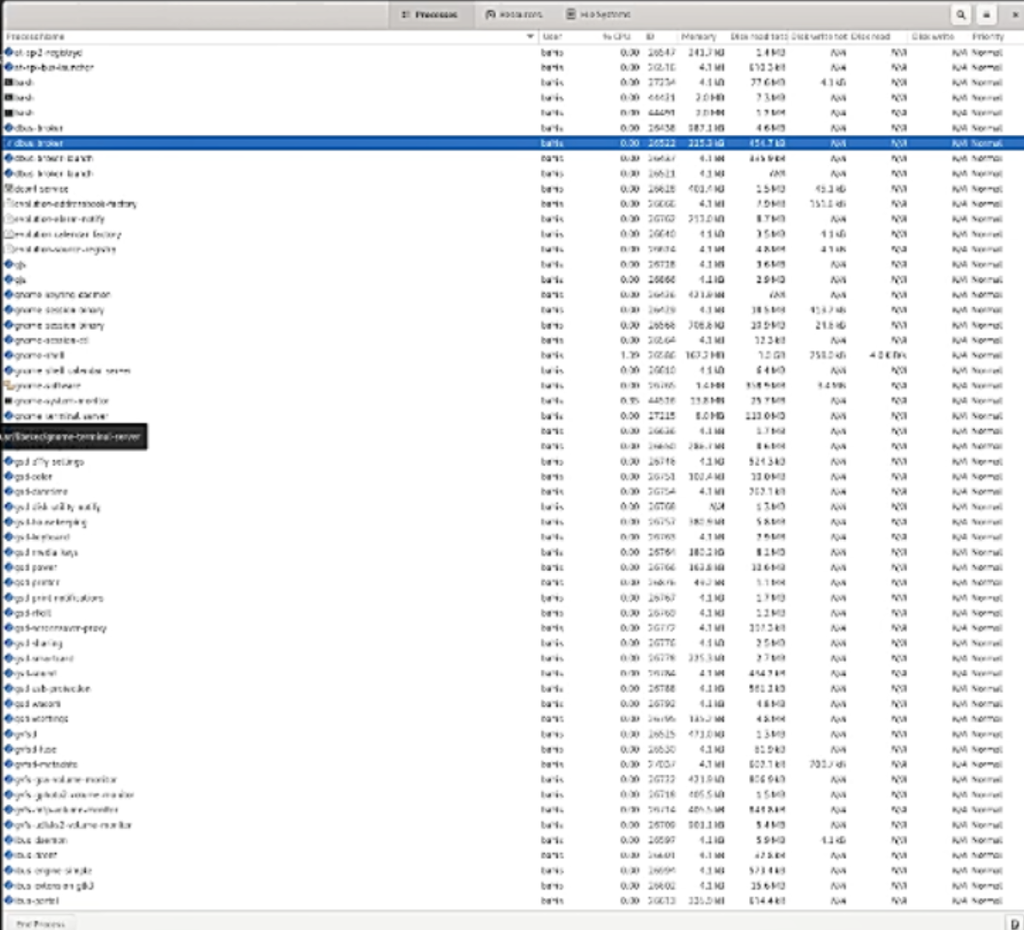

Рисунок 8: Запуск gnome-system-monitor на сервере

- Установлен пакет `lnav` через `dnf`
- Подтверждена успешная установка версии `0.11.1-1.el9`

[figure not shown]

Рисунок 9: Установка lnav на сервере

[figure not shown]

Рисунок 10: Просмотр журналов сервера в lnav

- Выполнен просмотр журналов клиента через `lnav`
- Отображаются записи `systemd`, `rsyslog`, `packagekit`
- Подтверждена корректная работа логирования

[figure not shown]

Рисунок 11: Просмотр журналов клиента в lnav

- Переход в `/vagrant/provision/server`
- Создание каталога `netlog/etc/rsyslog.d`
- Копирование `netlog-server.conf`
- Подготовка структуры provisioning

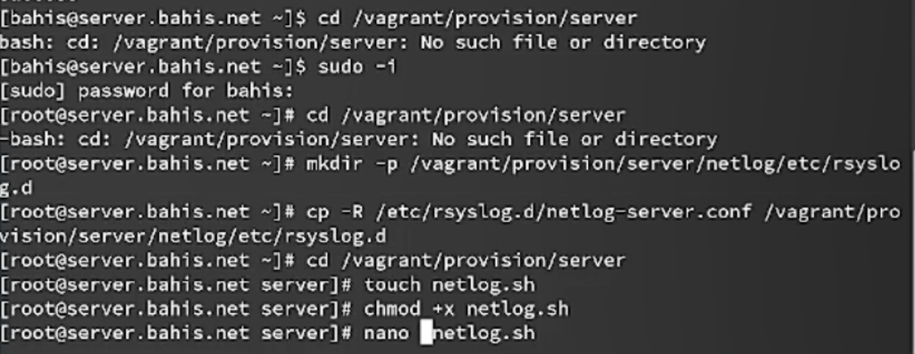

Рисунок 12: Создание каталога netlog и копирование конфигурации rsyslog

- Создан исполняемый скрипт `netlog.sh`
- Назначены права выполнения
- Добавлена автоматическая настройка
- Копирование файлов в `/etc`
- Восстановление контекстов SELinux
- Открытие порта 514
- Перезапуск `rsyslog`

[figure not shown]

Рисунок 13: Содержимое скрипта netlog.sh для автоматической настройки

- Переход в `/vagrant/provision/client`
- Создание каталога `netlog/etc/rsyslog.d`
- Копирование `netlog-client.conf`

[figure not shown]

Рисунок 14: Создание каталога netlog и копирование конфигурации клиента

[figure not shown]

Рисунок 15: Содержимое скрипта netlog.sh на клиенте

- В `Vagrantfile` добавлен блок provisioning для сервера
- Указан скрипт `provision/server/netlog.sh`
- Сохранена последовательность выполнения

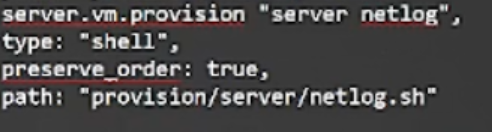

Рисунок 16: Добавление provisioning для сервера в Vagrantfile

- Добавлен аналогичный блок для клиента
- Указан скрипт `provision/client/netlog.sh`
- Обеспечена автоматическая настройка при запуске ВМ

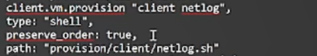

Рисунок 17: Добавление provisioning для клиента в Vagrantfile

# Выводы

## Выводы

- Настроено централизованное журналирование на базе `rsyslog`
- Организован приём журналов по TCP 514 на сервере
- Реализовано перенаправление сообщений с клиента
- Подтверждена корректность работы через `/var/log/messages` и `lnav`
- Реализована автоматизация через provisioning-скрипты
- Обеспечена воспроизводимость конфигурации
- Создана функционирующая система централизованного сбора журналов